# Project_5-Prediction_of_Drinking_Water_Potability

Tiffany & Fahad

11/09/2021

# Project #5: Drinking Water Potability

## Description:

Context Access to safe drinking water is essential to health, a basic human right, and a component of effective policy for health protection. This is important as a health and development issue at a national, regional, and local level. In some regions, it has been shown that investments in water supply and sanitation can yield a net economic benefit, since the reductions in adverse health effects and health care costs outweigh the costs of undertaking the interventions.

## Null Hypothesis:

There is no relationship between optimal levels of chemical components contained in treated water and portability of consumed water.

## Alternative Hypothesis:

Two or more optimal levels of combined features are cause for making the water not potable.

See if you can find any other trends in the data to predict portability of consumed water or find any clear indications of relationships between the predictors.

## Content:

The drinkingwaterpotability.csv file contains water quality metrics for 3276 different water bodies. 1. **pH value**: PH is an important parameter in evaluating the acid-base balance of water. It is also the indicator of the acidic or alkaline condition of water status. WHO has recommended the maximum permissible limit of pH from 6.5 to 8.5. The current investigation ranges were 6.52–6.83 which are in the range of WHO standards. 2. **Hardness**: Hardness is mainly caused by calcium and magnesium salts. These salts are dissolved from geologic deposits through which water travels. The length of time water is in contact with hardness-producing material helps determine how much hardness there is in raw water. Hardness was originally defined as the capacity of water to precipitate soap caused by Calcium and Magnesium. 3. **Solids** (Total dissolved solids - TDS): Water has the ability to dissolve a wide range of inorganic and some organic minerals or salts such as potassium, calcium, sodium, bicarbonates, chlorides, magnesium, sulfates, etc. These minerals produced an unwanted taste and diluted color in the appearance of water. This is the important parameter for the use of water. The water with a high TDS value indicates that water is highly mineralized. The desirable limit for TDS is 500 mg/l and the maximum limit is 1000 mg/l which is prescribed for drinking purposes. 4. **Chloramines**: Chlorine and chloramine are the major disinfectants used in public water systems. Chloramines are most commonly formed when ammonia is added to chlorine to treat drinking water. Chlorine levels up to 4 milligrams per liter (mg/L or 4 parts per million (ppm)) are considered safe in drinking water. 5. **Sulfate**: Sulfates are naturally occurring substances that are found in minerals, soil, and rocks. They are present in ambient air, groundwater, plants, and food. The principal commercial use of sulfate is in the chemical industry. Sulfate concentration in seawater is about 2,700 milligrams per liter (mg/L). It ranges from 3 to 30 mg/L in most freshwater supplies, although much higher concentrations (1000 mg/L) are found in some geographic locations. 6. **Conductivity**: Pure water is not a good conductor of electric current rather’s a good insulator. An increase in ions concentration enhances the electrical conductivity of water. Generally, the amount of dissolved solids in water determines electrical conductivity. Electrical conductivity (EC) actually measures the ionic process of a solution that enables it to transmit current. According to WHO standards, EC value should not exceed 400 μS/cm. 7. **Organic_carbon**: Total Organic Carbon (TOC) in source waters comes from decaying natural organic matter (NOM) as well as synthetic sources. TOC is a measure of the total amount of carbon in organic compounds in pure water. According to US EPA < 2 mg/L as TOC in treated / drinking water, and < 4 mg/Lit in source water which is use for treatment. 8. **Trihalomethanes**: THMs are chemicals that may be found in water treated with chlorine. The concentration of THMs in drinking water varies according to the level of organic material in the water, the amount of chlorine required to treat the water, and the temperature of the water that is being treated. THM levels up to 80 ppm are considered safe in drinking water. 9. **Turbidity**: The turbidity of water depends on the quantity of solid matter present in the suspended state. It is a measure of the light-emitting properties of water and the test is used to indicate the quality of waste discharge with respect to the colloidal matter. The mean turbidity value obtained for Wondo Genet Campus (0.98 NTU) is lower than the WHO recommended value of 5.00 NTU. 10. **Potability**: Indicates if water is safe for human consumption where 1 means Potable and 0 means Not potable.

Read dataset and other assets remotely from AWS-S3

```r
#AWS environment setup which is not secured but we have it for temporary usage to access AWS resources
# Sys.setenv(
#   AWS_ACCESS_KEY_ID = "AKIA4CSJQNSCJA74HAIJ",
#   AWS_SECRET_ACCESS_KEY = "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",
#   AWS_REGION = "us-east-1")
```

```r
# Connecting to RPostgreSQL
# drv <- dbDriver('PostgreSQL')
# db <- 'db-instance-hs631'
# host_db <- 'db-instance-hs631.cllvlwixyq2w.us-east-1.rds.amazonaws.com'
# db_port <- '5432'
# db_user <- 'postgres'
# db_password <- 'postgresDB2021'
# Will continou working on the integration later as not required by the project
# conn <- dbConnect(drv, dbname=db, host=host_db, port=db_port, user=db_user, password=db_password)
#
# # Connecting to RPostgres
# # with the same connection variables without 'drv'
#
# conn <- dbConnect(RPostgres::Postgres(), dbname = db2, host=host_db, port=db_port, user=db_user, password=db_password)
#
```

```r
#Read dataset from Github
x <- getURL("https://raw.githubusercontent.com/nitieaj/Project_5-Prediction_of_Drinking_Water_Portability/main/data/drinking_water_potability.csv")
dw.potability <- read.csv(text = x)
#dw.potability <- read.csv("./Data/drinking_water_potability.csv", header = TRUE, sep = ",")%>% glimpse()#using glimpse to have a quick look t the variables we have and the dimensions of the dataset
```

We have about 3,275 * 10 dimension dataset

```r
str(dw.potability)
```

```
## 'data.frame':    3276 obs. of  10 variables:
##  $ ph             : num  4.68 3.72 8.1 8.32 9.09 ...
##  $ Hardness       : num  205 129 224 214 181 ...
##  $ Solids         : num  20791 18630 19910 22018 17979 ...
##  $ Chloramines    : num  7.3 6.64 9.28 8.06 6.55 ...
##  $ Sulfate        : num  369 NA NA 357 310 ...
##  $ Conductivity   : num  564 593 419 363 398 ...
##  $ Organic_carbon : num  10.4 15.2 16.9 18.4 11.6 ...
##  $ Trihalomethanes: num  87 56.3 66.4 100.3 32 ...
##  $ Turbidity      : num  2.96 4.5 3.06 4.63 4.08 ...
##  $ Potability     : int  0 0 0 0 0 0 0 0 0 0 ...
```

```r
library(janitor) #using janitor library to use clean_names function to:
                    #Returns names with only lowercase letters, with _ as a separator
                    #Handles special characters and spaces
                    #Appends numbers to duplicated names
                    #Converts “%” to “percent” to retain meaning

dw.potability <- dw.potability %>%
  mutate(Potability = as.factor(Potability)) %>% #convert Int to factor in *Potability* feature
  clean_names() %>% glimpse()
```

```
## Rows: 3,276
## Columns: 10
## $ ph              <dbl> 4.678920, 3.716080, 8.099124, 8.316766, 9.092223, 5.58…
## $ hardness        <dbl> 204.8905, 129.4229, 224.2363, 214.3734, 181.1015, 188.…
## $ solids          <dbl> 20791.32, 18630.06, 19909.54, 22018.42, 17978.99, 2874…
## $ chloramines     <dbl> 7.300212, 6.635246, 9.275884, 8.059332, 6.546600, 7.54…
## $ sulfate         <dbl> 368.5164, NA, NA, 356.8861, 310.1357, 326.6784, 393.66…
## $ conductivity    <dbl> 564.3087, 592.8854, 418.6062, 363.2665, 398.4108, 280.…
## $ organic_carbon  <dbl> 10.379783, 15.180013, 16.868637, 18.436525, 11.558279,…
## $ trihalomethanes <dbl> 86.99097, 56.32908, 66.42009, 100.34167, 31.99799, 54.…
## $ turbidity       <dbl> 2.963135, 4.500656, 3.055934, 4.628771, 4.075075, 2.55…
## $ potability      <fct> 0, 0, 0, 0, 0, 0, 0, 0, 0, 0, 0, 0, 0, 0, 0, 0, 0, 0, …
```

#Now, our variables are in lower case which is intutive whhile we’re coding

```r
summary(dw.potability)
```

```
##        ph            hardness          solids         chloramines
##  Min.   : 0.000   Min.   : 47.43   Min.   :  320.9   Min.   : 0.352
##  1st Qu.: 6.092   1st Qu.:176.85   1st Qu.:15666.7   1st Qu.: 6.127
##  Median : 7.036   Median :196.97   Median :20927.8   Median : 7.130
##  Mean   : 7.080   Mean   :196.37   Mean   :22014.1   Mean   : 7.122
##  3rd Qu.: 8.062   3rd Qu.:216.67   3rd Qu.:27332.8   3rd Qu.: 8.115
##  Max.   :14.000   Max.   :323.12   Max.   :61227.2   Max.   :13.127
##  NA's   :490
##     sulfate       conductivity   organic_carbon  trihalomethanes
##  Min.   :129.0   Min.   :181.5   Min.   : 2.20   Min.   :  0.738
##  1st Qu.:307.7   1st Qu.:365.7   1st Qu.:12.07   1st Qu.: 55.845
##  Median :333.1   Median :421.9   Median :14.22   Median : 66.622
##  Mean   :333.6   Mean   :426.2   Mean   :14.28   Mean   : 66.396
##  3rd Qu.:359.7   3rd Qu.:481.8   3rd Qu.:16.56   3rd Qu.: 77.337
##  Max.   :481.0   Max.   :753.3   Max.   :28.30   Max.   :124.000
##  NA's   :743                                     NA's   :162
##    turbidity     potability
##  Min.   :1.450   0:1998
##  1st Qu.:3.440   1:1278
##  Median :3.955
##  Mean   :3.967
##  3rd Qu.:4.500
##  Max.   :6.739
##
```

```r
dw.potability %>%
  summarise_all(~ sum(is.na(.)))
```

```
##    ph hardness solids chloramines sulfate conductivity organic_carbon
## 1 490        0      0           0     743            0              0
##   trihalomethanes turbidity potability
## 1             162         0          0
```

#We have three features are missing values and they are orded bellow by the highest NA values:

**sulfate** = 743 missing values **ph** = 490 missing values **trihalomethanes** = 162 missing values

```r
#Calling the required libraries for this chunk
#library(ggplot2) # For vizulization computation
#library(skimr)#which is similar to summary function, but with opinionated in its defaults
#library(scales)# to converting from data values to perceptual properties
#library(forcats)#to handle categorical variables, variables that have a fixed and known set of possible values. Factors are also helpful for reordering character vectors to improve display


#creating a new variables that filter our dataset by using skim function and show the output as table
skim.dw.pot <- dw.potability %>%  skim() %>%
   filter(n_missing != 0) %>%
   as_tibble() %>%
   mutate(n_missing, skim_variable, complete_rate) %>% #Mutate targeted variables produced by Skim function such as skim_variable, n_missing, complete_rate  to help us with missing rate classification
   mutate(missing_rate = round(abs(complete_rate - 1) * 100, 1)) # by subtracting 1r from the complete_rate feature and times that by 100


skim.dw.pot
```

```
## # A tibble: 3 × 16
##   skim_type skim_variable   n_missing complete_rate factor.ordered factor.n_unique
##   <chr>     <chr>               <int>         <dbl> <lgl>                    <int>
## 1 numeric   ph                    490         0.850 NA                          NA
## 2 numeric   sulfate               743         0.773 NA                          NA
## 3 numeric   trihalomethanes       162         0.951 NA                          NA
## # … with 10 more variables: factor.top_counts <chr>, numeric.mean <dbl>,
## #   numeric.sd <dbl>, numeric.p0 <dbl>, numeric.p25 <dbl>, numeric.p50 <dbl>,
## #   numeric.p75 <dbl>, numeric.p100 <dbl>, numeric.hist <chr>,
## #   missing_rate <dbl>
```

We will visulize the **skim_variable**, **n_missing, mean** as a missing value rate aganist the atrgeted features **sulfate**, **ph**, **trihalomethanes**

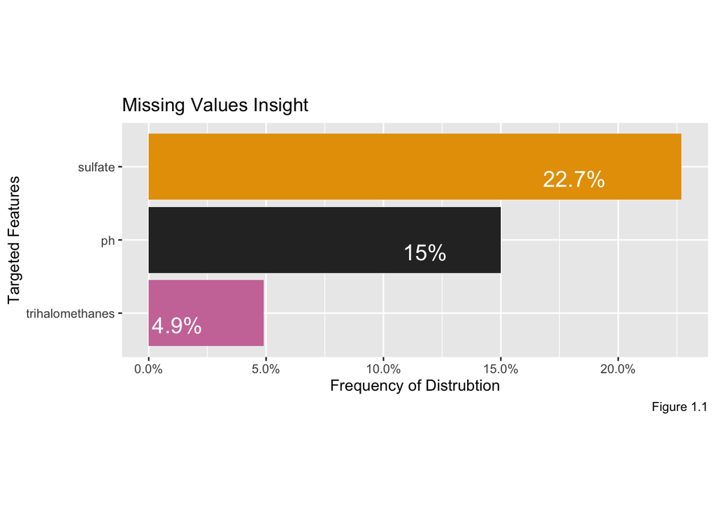

```r
skim.dw.pot %>%
  ggplot(aes(
     x = fct_reorder(skim_variable, n_missing, mean),
     y = missing_rate,
     fill = skim_variable, #we fill skim_variable and n_missing, and
     label = paste0(missing_rate, "%")
   )) +
   geom_col(width = .9) +
   geom_text(
     size = 5.5,
     hjust = 2.2,
     vjust = 1.25,
     col = "white"
   ) +
   coord_flip() + theme(aspect.ratio = .4) +
   theme(
     legend.position = "none"
   ) +
   scale_y_continuous(label = label_percent(scale = 1)) +
   scale_fill_manual(values = c("#2D2D2D",
                                "#E69F00",
                                "#CC79A7")) +
   labs(title = "Missing Values Insight", x = "Targeted Features", y = "Frequency of Distrubtion", caption = "Figure 1.1")
```

**sulfate** = 743 missing values ~ 22.7% **ph** = 490 missing values ~ 15% **trihalomethanes** = 162 missing values ~ 4.9%

```r
#Impute the missing values wiht the mean which is a naive solution to make this missing values filled
dw.potability <- dw.potability %>%
  group_by(potability) %>%
  mutate(across(where(is.numeric), ~if_else(is.na(.), mean(., na.rm = T), as.numeric(.)))) %>%
  ungroup()

head(dw.potability)
```

```
## # A tibble: 6 × 10
##      ph hardness solids chloramines sulfate conductivity organic_carbon
##   <dbl>    <dbl>  <dbl>       <dbl>   <dbl>        <dbl>          <dbl>
## 1  4.68     205. 20791.        7.30    369.         564.          10.4
## 2  3.72     129. 18630.        6.64    335.         593.          15.2
## 3  8.10     224. 19910.        9.28    335.         419.          16.9
## 4  8.32     214. 22018.        8.06    357.         363.          18.4
## 5  9.09     181. 17979.        6.55    310.         398.          11.6
## 6  5.58     188. 28749.        7.54    327.         280.           8.40
## # … with 3 more variables: trihalomethanes <dbl>, turbidity <dbl>,
## #   potability <fct>
```

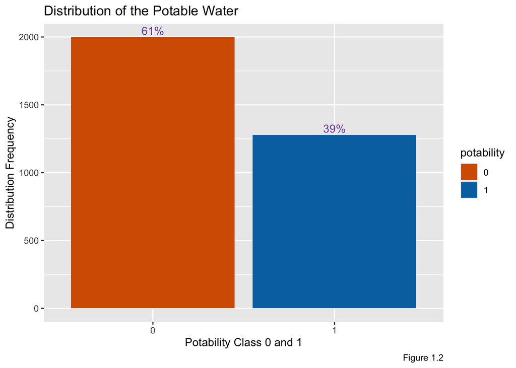

```r
dw.potability %>%
  dplyr::select(potability) %>%
  count(potability) %>%
  mutate(percent = paste0(round(n / sum(n) * 100), "%"), 2) %>%
  ggplot(aes(
    x = potability,
    y = n,
    label = percent,
    fill = potability
  )) +
  geom_col() +
  geom_text(vjust = - 0.3, color = "#7C4EA8") +
  scale_fill_manual(values = c("#D55E00", "#0072B2")) +
  labs(
    title = "Distribution of the Potable Water",
    x = "Potability Class 0 and 1",
    y = "Distribution Frequency",
    caption = "Figure 1.2"
  )
```

##Part 2 Imputation:

#We assume that the missing values are made randomly, and we prefer to enhance the imputation with incorperating two algorthims such as KNN ~ K-nearest neighbors algorithm, however to determine the k value is a challenging part. Therefore, imputation on the a similar value is better than the entire dataset. Hence, we proposed the follwoing approache to enhance the imputation perfermoance and bring the high imputation accuracy:

1. We proposed KI algorithm which is a hybrid missing data by using K-nearest neighbors algorithm along with iterative imputation algorithm and the global correlation structure among the selected value. However, It is not the optimal solution for the large scale dataset.
2. After the KI has been proceed, the will propose the FCKI algorithm which is similar to Euclidean distance measure to enhance the KI algorthim because FCKI combine fuzzy c-mean clustering, k-nearest neighbor algorithm, and iterative imputation algorithms by imputing the missing values in the dataset where the c-mean has been selected because the the missing value might belong a multiple clusters at the the same time.